# Data Analytics for Business

## Session 2-3, Dimensionality Reduction and Derived Attributes (Technical Slides)

T. Evgeniou  
INSEAD

## Why this class? Three goals

1. Organizational Level: Develop your intuition about identifying data analytics opportunities and their implementation challenges
2. Project Level: Learn how to approach data analytics projects
3. Analysis Level: Learn how to perform, read, and use key data analytics methods.

## Data Analytics Processes: Iterative Process Cycle with a Lifetime

Step 1: Defining the Objective(s)

Step 2: Data Preparation and Exploration

Step 3: Analysis

Step 4: Performance Assessment

## What is Dimensionality Deduction and Factor Analysis?

Derive new variables which are (linear) combinations of the original ones and capture most of the information in the original data.

Is often used as a first step in Data Analytics

Can also be used to solve multicollinearity issues in regression

## Factor Analysis: Key idea

1. Transform the original selected variables into a smaller set of factors
2. Understand the underlying structure of the data and the new factors
3. Use the factors for subsequent analysis

## Key Questions

1. Can we really simplify the data by grouping the raw attributes?
2. How many factors should we use?
3. How good are the factors we found?
4. How interpretable and actionable are the factors we found?

## Dimensionality Reduction and Factor Analysis: 6 (Easy) Steps

1. Confirm the data is metric
2. Decide whether to scale or standardize the data
3. Check the correlation matrix to see if Factor Analysis makes sense
4. Develop a scree plot and decide on the number of factors to be derived
5. Interpret the factors (consider factor rotations - technical but useful)
6. Save factor scores for subsequent analyses

## Applying Factor Analysis: Evaluating MBA Applications

Variables available:

- GPA
- GMAT score
- Scholarships, fellowships won
- Evidence of Communications skills
- Prior Job Experience
- Organizational Experience
- Other extra curricular achievements

Which variables are correlated? What do these variables capture?

## Example Factors

## Step 1: Confirm the data are metric

## Step 2: Decide whether to scale or standardize the data: Summary Statistics

## Data Standardization: Example Code

```r
ProjectDatafactor_scaled=apply(ProjectDataFactor,2, function(r) {
  if (sd(r)!=0) {
    res=(r-mean(r))/sd(r)
    } else {
      res=0*r; res
      }
  })
```

## Standardized Data: Summary Statistics

## Step 3: Check correlation matrix to see if Factor Analysis makes sense

|  | Q1_2_When buying a boat getting the lowest price is more important than the boat brand | Q1_3_The brand of boat I buy says a lot about who I am | Q1_4_I only consider buying a boat from a reputable brand | Q1_5_I am willing to pay a premium for a brand with a reputation for high quality | Q1_9_I see my boat as a status symbol | Q1_11_I tend to perform minor boat repairs and maintenance on my own | Q1_18_Boating gives me a feeling of adventure | Q1_21_Boating helps me escape from everyday life and relax | Q1_24_Boating gives me an outlet to socialize with family and or friends | Q1_28_Boating is my true passion in life |
| --- | --- | --- | --- | --- | --- | --- | --- | --- | --- | --- |
| Q1_2_When buying a boat getting the lowest price is more important than the boat brand | 1.00 | -0.03 | -0.21 | -0.21 | 0.09 | 0.04 | -0.04 | -0.10 | -0.08 | 0.02 |
| Q1_3_The brand of boat I buy says a lot about who I am | -0.03 | 1.00 | 0.26 | 0.40 | 0.58 | 0.10 | 0.24 | 0.18 | 0.23 | 0.43 |
| Q1_4_I only consider buying a boat from a reputable brand | -0.21 | 0.26 | 1.00 | 0.37 | 0.17 | 0.06 | 0.18 | 0.18 | 0.23 | 0.21 |
| Q1_5_I am willing to pay a premium for a brand with a reputation for high quality | -0.21 | 0.40 | 0.37 | 1.00 | 0.33 | 0.07 | 0.23 | 0.19 | 0.25 | 0.33 |
| Q1_9_I see my boat as a status symbol | 0.09 | 0.58 | 0.17 | 0.33 | 1.00 | 0.06 | 0.22 | 0.14 | 0.23 | 0.40 |
| Q1_11_I tend to perform minor boat repairs and maintenance on my own | 0.04 | 0.10 | 0.06 | 0.07 | 0.06 | 1.00 | 0.11 | 0.13 | 0.08 | 0.18 |
| Q1_18_Boating gives me a feeling of adventure | -0.04 | 0.24 | 0.18 | 0.23 | 0.22 | 0.11 | 1.00 | 0.47 | 0.42 | 0.31 |
| Q1_21_Boating helps me escape from everyday life and relax | -0.10 | 0.18 | 0.18 | 0.19 | 0.14 | 0.13 | 0.47 | 1.00 | 0.42 | 0.26 |
| Q1_24_Boating gives me an outlet to socialize with family and or friends | -0.08 | 0.23 | 0.23 | 0.25 | 0.23 | 0.08 | 0.42 | 0.42 | 1.00 | 0.25 |
| Q1_28_Boating is my true passion in life | 0.02 | 0.43 | 0.21 | 0.33 | 0.40 | 0.18 | 0.31 | 0.26 | 0.25 | 1.00 |

## Step 4. Develop a scree plot and decide on the number of factors to be derived

For the method considered here (Principal Component Analysis):

- If there are n variables we will have n factors in total
- First factor will explain most of the variance, second next and so on.

Eigenvalues and Variance Explained by Factors

- each factor will have an associated eigenvalue - which corresponds to the amount of variance explained by that factor
- with standardized variables each variable has a variance of 1, and the sum of all eigenvalues with n raw attributes is n
- we would like to capture as much of the total variance as possible, while keeping as few factors as possible

## How many factors?

Three criteria to use:

- Eigenvalue > 1
- Cumulative variance explained
- "Elbow" in the Scree plot

## For visualization, let's supress the small numbers...

## What Factor Loads "Look Good"? Three Technical Quality Criteria

1. For each factor (column) only a few loadings are large (in absolute value)
2. For each raw attribute (row) only a few loadings are large (in absolute value)
3. Any pair of factors (columns) should have different "patterns" of loading

## Step 6. Save factor scores for subsequent analyses

## Using the Factor Scores: Perceptual Maps

## Factor Analysis: Some (Technical) Concepts

1. Correlation
2. Variance explained (eigenvalues)
3. Scree plot
4. varimax rotation
5. Factor Loadings ("components")
6. Factor scores

## Key Questions

1. How many factors should we use? Why? Quantitative and Qualitative criteria
2. How can we name and interpret the factors?
3. What are some issues to consider?

## Next Class: Cluster Analysis for Segmentation

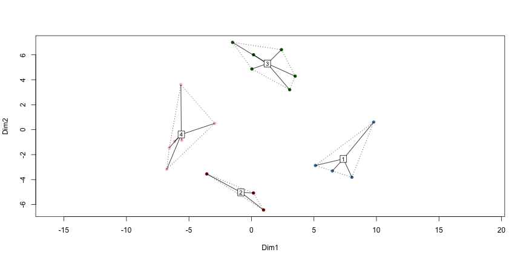